# SAMC Comparison

### Setup

You must install from github, from the **paper** branch (important).

```r
devtools::install_github("LandSciTech/LSTDConnect",
                         ref = "paper")
```

We load the package along with `raster` and `samc`. We also load the `microbenchmark` package to benchmark code performance. We will use ggplot for some visualizations.

```r
library(LSTDConnect)
library(raster)
library(samc)
```

```r
library(microbenchmark)
library(ggplot2)
```

Then, access the buolt-in dataset, `ghm`. This raster represent habitat resistance for a small part of Canada (100 cells squares, at a resolution of 1 km).

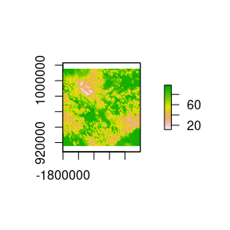

```r
res <- LSTDConnect::ghm
plot(res)
```

### Running SAMC in paralell

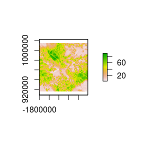

```r
occ <- 101 - res
plot(occ)
```

Mortality is built from resisatnce such as when resistance is larger than 80, mortality is high whereas under 80, it is low.

```r
high_mort <- 0.25
low_mort <- 0.01
cutoff <- 80

mort <- res
mort[mort >= cutoff] <- high_mort
mort[mort < cutoff] <- low_mort
```

We first run `LSTDConnect::samc` to prepare the data for the computation.

```r
samc_cache <- LSTDConnect::samc(resistance = res, absorption = mort,
                                directions = 4)
```

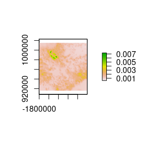

```r
dists <- LSTDConnect::distribution(samc = samc_cache, occ = occ, time = 1000)
plot(dists$occ)
```

### Comparison with the original samc package

We can compare the results with those given by the `samc` package.

```r
tr_list <- list(fun = function(x) 1 / mean(x),
                dir = 8,
                sym = TRUE)

samc_cache_comp <- samc::samc(data = res, absorption = mort, tr_args = tr_list)
```

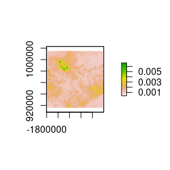

```r
dists_comp <- samc::distribution(samc = samc_cache_comp, occ = occ, time = 1000)
dists_mapped <- map(samc_cache_comp, dists_comp)
plot(dists_mapped)
```

Let’s look at the differences. We can see the error is extremely small

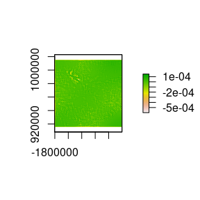

```r
diff <- dists_mapped - dists$occ
plot(diff)
```

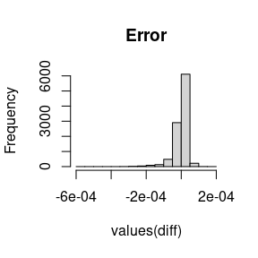

```r
hist(values(diff), main = "Error")
```

Let’s now benchmark and compare the speed of these two packages by running each process 100 times

```r
t <- 1000

samc_obj <- samc::samc(data = res,
                       absorption = mort,
                       tr_args = tr_list)
samc_obj_custom <- LSTDConnect::samc(resistance = res,
                                     absorption = mort,
                                     directions = 8)

mbm <- microbenchmark(
  "samc" = {
    short_disp <- samc::distribution(samc = samc_obj,
                                     occ = mort,
                                     time = t)
    gc()
  },
  "LSTDConnect" = {
    short_disp_custom <- LSTDConnect::distribution(samc = samc_obj_custom,
                                                   occ = occ,
                                                   time = t)
    gc()
  },
  times = 100,
  unit = "s")
mbm
```

```
#> Unit: seconds
#>         expr       min        lq      mean    median        uq       max neval
#>         samc 0.2873064 0.2972756 0.3060093 0.3028995 0.3115687 0.3499686   100
#>  LSTDConnect 0.2271273 0.2389779 0.2527764 0.2465298 0.2559053 0.4914924   100
```

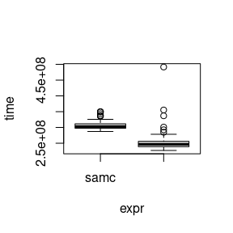

```r
plot(mbm)
```